# Normalized Power Prior : normal likelihood, beta prior on the power parameter, noninformative initial prior, known sampling variance

Tristan Fauvel, Quinten Health

2024-06-04

## Introduction

The aim of this document is to illustrate the implementation of the Normalized Power Prior in the case where the treatment effect follows a normal distribution.

## Set working directory, import functions

## Load the Belimumab case study configuration

Load the simulation configuration and the Belimumab case study configuration from YAML files.

```r
set.seed(42)
simulation_config <- yaml::yaml.load_file("./inst/conf/full/simulation_config.yml")
case_study_config <- yaml::yaml.load_file("./inst/conf/case_studies/belimumab.yml")
```

## Specific scenario

Here, we choose the following :

```r
target_sample_size_per_arm <- as.integer(case_study_config$target$total / 2)
control_drift <- 0
treatment_drift <- 0.4 # Note that drift (in treatment effect) = treatment_drift - control_drift
```

The derivation for the normalized power prior can be found in Pawel et al (2023): https://doi.org/10.1002/sta4.591

With known standard error $\sigma_T$ of the estimate $\theta_T$, a Beta prior on the power parameter $\gamma \sim \operatorname{Be}(p, q)$. This choice leads to the normalized power prior :

$$\pi\left(\theta, \gamma \mid D_S\right)=\frac{\mathcal{L}\left(D_S \mid
\theta\right)^\gamma \pi(\gamma)}{\int_{-\infty}^{+\infty}
\mathcal{L}\left(D_S \mid \theta^{\prime}\right)^\gamma d
\theta^{\prime}}=\mathcal{N}\left(\theta \mid \hat{\theta}_S, \sigma_S^2
/ \gamma\right) \operatorname{Be}(\gamma \mid p, q)$$

Combining this prior with the likelihood of the target study data produces a joint posterior for $\theta$ and $\gamma$, that is,
$$\pi\left(\theta, \gamma \mid D, D_S\right)=\frac{L(D \mid \theta)
\pi\left(\theta, \gamma \mid D_S\right)}{\int_0^1
\int_{-\infty}^{\infty} L\left(D \mid \theta^{\prime}\right)
\pi\left(\theta^{\prime}, \gamma^{\prime} \mid D_S\right) d
\theta^{\prime} d \gamma^{\prime}}=\frac{\mathcal{N}\left(\hat{\theta}_T
\mid \theta, \sigma_T^2\right) \mathcal{N}\left(\theta \mid
\hat{\theta}_S, \sigma_S^2 / \gamma\right) \operatorname{Be}(\gamma \mid
p, q)}{\int_0^1 \mathcal{N}\left(\hat{\theta}_T \mid \hat{\theta}_S,
\sigma_T^2+\sigma_S^2 / \gamma^{\prime}\right)
\operatorname{Be}\left(\gamma^{\prime} \mid p, q\right) d
\gamma^{\prime}},$$
from which a marginal posterior for $\gamma$ can be obtained by integrating out $\theta$, that is,
$$\pi\left(\gamma \mid D, D_S\right)=\int_{-\infty}^{+\infty}
\pi\left(\theta, \gamma \mid D, D_S\right) d
\theta=\frac{\mathcal{N}\left(\hat{\theta}_T \mid \hat{\theta}_S,
\sigma_T^2+\sigma_S^2 / \gamma\right) \operatorname{Be}(\gamma \mid p,
q)}{\int_0^1 \mathcal{N}\left(\hat{\theta}_T \mid \hat{\theta}_S,
\sigma_T^2+\sigma_S^2 / \gamma^{\prime}\right)
\operatorname{Be}\left(\gamma^{\prime} \mid p, q\right) d
\gamma^{\prime}} .$$
## Create data objects

Create a source_data instance, where information about the source data is stored

```r
source_data <- ObservedSourceData$new(case_study_config)
print(source_data)
```

```
## <ObservedSourceData>
##   Public:
##     clone: function (deep = FALSE)
##     endpoint: binary
##     initialize: function (case_study_config)
##     source_control_rate: 0.387900355871886
##     source_sample_size_control: 562
##     source_sample_size_treatment: 563
##     source_standard_error: 0.120717471402273
##     source_total_sample_size: 1125
##     source_treatment_effect_estimate: 0.480132045646795
##     source_treatment_rate: 0.506216696269982
##     summary_measure_likelihood: normal
##     to_dict: function ()
```

Set the observed target data (in the paediatrics population)

```r
target_data <- ObservedTargetData$new(treatment_effect_estimate = case_study_config$target$treatment_effect, treatment_effect_standard_error = case_study_config$target$standard_error, target_sample_size_per_arm = as.integer(case_study_config$target$total / 2), summary_measure_likelihood = case_study_config$summary_measure_likelihood)
```

## Create the model

Now, we define the model we want to use for inferring the treatment effect in the target study.

We reuse the code published in Pawel et al (2023, https://doi.org/10.1002/sta4.591). Marginal posterior densities are computed by numerical integration:

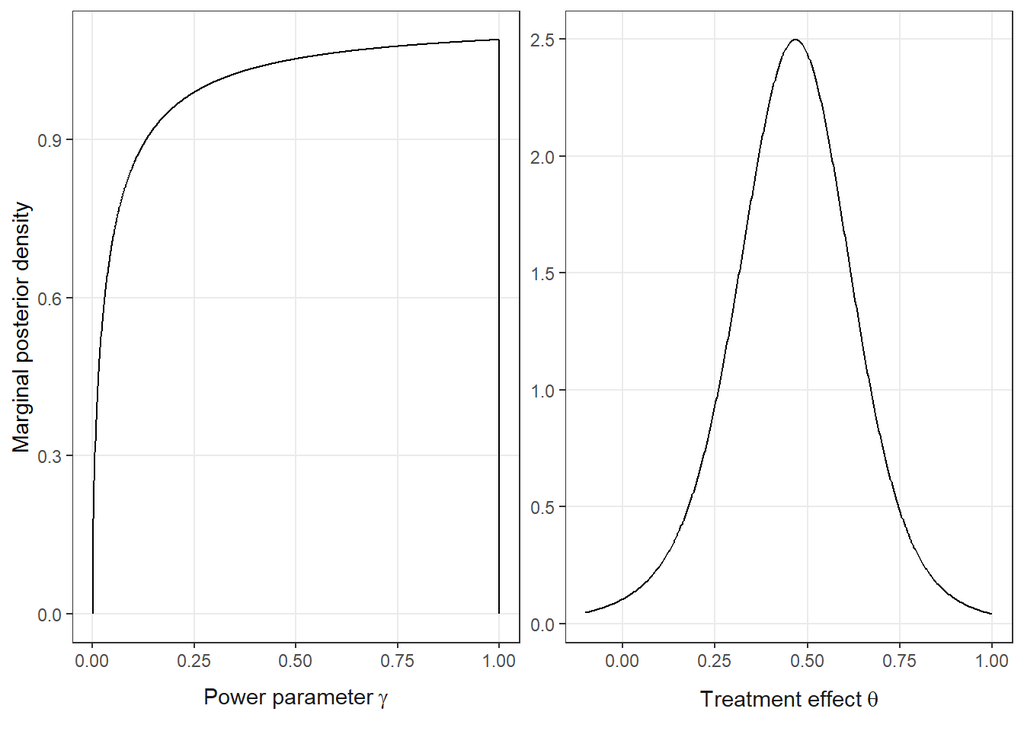

```r
method <- "NPP"
# here, we choose the parameters so that the prior on the power parameter is Beta(1,1)
method_parameters <- list(
  initial_prior = "noninformative",
  power_parameter_prior_mean = 0.5,
  power_parameter_prior_std = sqrt(1 / 12)
)


## Parameters of the Beta prior on the power parameter:
ksi <- method_parameters$power_parameter_prior_mean
omega <- method_parameters$power_parameter_prior_std^2 / (ksi * (1 - ksi) - method_parameters$power_parameter_prior_std^2)
p <- ksi / omega
q <- (1 - ksi) / omega
power_parameter_range <- seq(0, 1, 0.001)
intFun <- function(gamma) {
  dnorm(x = target_data$sample$treatment_effect_estimate, mean = source_data$treatment_effect_estimate, sd = sqrt(target_data$sample$treatment_effect_standard_error^2 + source_data$standard_error^2 / gamma)) *
    dbeta(x = gamma, shape1 = p, shape = q)
}
normconst <- integrate(f = intFun, lower = 0, upper = 1)$value
power_parameter_pdf <- intFun(gamma = power_parameter_range) / normconst


## marginal posterior of theta for data example
treatment_effect_range <- seq(-0.1, 1, length.out = 500)
treatment_effect_pdf <- sapply(X = treatment_effect_range, FUN = function(t) {
  integrate(f = function(gamma) {
    dnorm(x = target_data$sample$treatment_effect_estimate, mean = t, sd = target_data$sample$treatment_effect_standard_error) *
      dnorm(x = t, mean = source_data$treatment_effect_estimate, sd = sqrt(source_data$standard_error^2 / gamma)) *
      dbeta(x = gamma, shape1 = p, shape2 = q) / normconst
  }, lower = 0, upper = 1)$value
})

## combine all into one data frame
power_parameter <- "'Power parameter' ~ gamma"
treatment_effect <- "'Treatment effect' ~ theta"
plotDF <- rbind(
  data.frame(x = treatment_effect_range, y = treatment_effect_pdf, parameter = treatment_effect),
  data.frame(x = power_parameter_range, y = power_parameter_pdf, parameter = power_parameter)
)
plotDF$parameter <- factor(x = plotDF$parameter, levels = c(power_parameter, treatment_effect))

## plot marginal posterior densities
ggplot2::ggplot(data = plotDF, ggplot2::aes(x = x, y = y)) +
  facet_wrap(~parameter,
    labeller = label_parsed,
    strip.position = "bottom", scales = "free"
  ) +
  geom_line(gamma = 0.8) +
  ggplot2::labs(x = NULL, y = "Marginal posterior density", linetype = "") +
  # scale_linetype_manual(values = linetypes, labels = scales::parse_format()) +
  theme_bw() +
  theme(
    legend.position = "top", panel.grid.minor = element_blank(),
    strip.background.x = element_blank(), strip.placement = "outside",
    strip.text = element_text(size = 11)
  )
```